# Gene Annotations: iPSC+LCL

Kushal K Dey & Joyce Hsiao

September 19, 2015

```r
library(CountClust)
suppressMessages(library(mygene))
library(knitr)
```

### Goal

From the Structure analysis, it seemed apparent that the iPSC and the LCL were clustering separately. Even for 2 clusters this was the case, and when we chose higher number of clusters, they were still catching the separation between iPSCs and the LCLs. In this script, we find which are the genes that are driving the clusters, their relative expression patterns in iPSCs and LCLs and finally the biological annotation of these genes.

### Extracting Cluster annotations of genes

```r
setwd('/Users/kushal/Documents/singleCell-method/project/iPSC+LCL/src')
ipsc_lcl_topics <- get(load("../../../project/rdas/topic_fit_ipsc_lcl.rda"));

theta <- ipsc_lcl_topics[[1]]$theta;
features <- ExtractTopFeatures(theta,top_features=10,method="poisson")

features_vec <- unique(as.vector(features));

class <- as.numeric(apply(theta[features_vec,], 1, which.max))

imp_gene_names <- rownames(theta[features_vec,]);

imp_genes_per_class <- lapply(1:dim(theta)[2], function(x) imp_gene_names[which(class==x)]);
```

The colors of the designated cluster numbers as per the Structure plot are in the order given below.

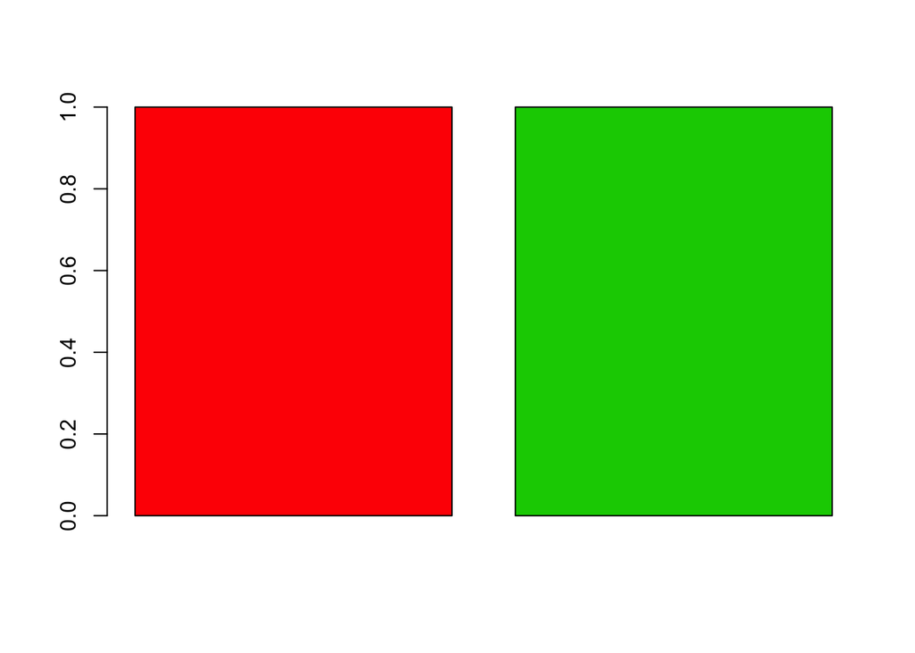

```r
barplot(rep(1,dim(theta)[2]),col=(2:(dim(theta)[2]+1)))
```

### Gene Annotations - Top genes driving clusters

The Ensemble IDS of the top genes that are highly expressed in iPSCs compared to the LCLs are the following. The summary information on genes which are significantly highly epressed in iPSCs compared to LCLs are the following.

```r
out <- queryMany(imp_genes_per_class[[1]], scopes="ensembl.gene", fields=c("name", "summary"), species="human");
```

```
## Finished
## Pass returnall=TRUE to return lists of duplicate or missing query terms.
```

```r
kable(as.data.frame(out))
```

| query | X_id | name | summary |
| --- | --- | --- | --- |
| ENSG00000198712 | 4513 | cytochrome c oxidase subunit II | NA |
| ENSG00000198938 | 4514 | cytochrome c oxidase III | NA |
| ENSG00000187514 | 728026 | prothymosin alpha-like | NA |
| ENSG00000187514 | 5757 | prothymosin, alpha | NA |
| ENSG00000174720 | 51574 | La ribonucleoprotein domain family, member 7 | This gene encodes a protein which is found in the 7SK snRNP (small nuclear ribonucleoprotein). This snRNP complex inhibits a cyclin-dependent kinase, positive transcription elongation factor b, which … |
| ENSG00000198899 | 4508 | ATP synthase F0 subunit 6 | NA |
| ENSG00000181163 | 4869 | nucleophosmin (nucleolar phosphoprotein B23, numatrin) | This gene encodes a phosphoprotein which moves between the nucleus and the cytoplasm. The gene product is thought to be involved in several processes including regulation of the ARF/p53 pathway. A num… |
| ENSG00000117450 | 5052 | peroxiredoxin 1 | This gene encodes a member of the peroxiredoxin family of antioxidant enzymes, which reduce hydrogen peroxide and alkyl hydroperoxides. The encoded protein may play an antioxidant protective role in c… |
| ENSG00000080824 | 3320 | heat shock protein 90kDa alpha (cytosolic), class A member 1 | The protein encoded by this gene is an inducible molecular chaperone that functions as a homodimer. The encoded protein aids in the proper folding of specific target proteins by use of an ATPase activ… |
| ENSG00000119705 | 81892 | SRA stem-loop interacting RNA binding protein | Steroid receptor RNA activator (SRA, or SRA1; MIM 603819) is a complex RNA molecule containing multiple stable stem-loop structures that functions in coactivation of nuclear receptors. SLIRP interacts… |
| ENSG00000164032 | 3015 | H2A histone family, member Z | Histones are basic nuclear proteins that are responsible for the nucleosome structure of the chromosomal fiber in eukaryotes. Nucleosomes consist of approximately 146 bp of DNA wrapped around a histon… |

The summary information of the genes which are significantly highly expressed in LCL compared to iPSCs

```r
out <- queryMany(imp_genes_per_class[[2]], scopes="ensembl.gene", fields=c("name", "summary"), species="human");
```

```
## Finished
## Pass returnall=TRUE to return lists of duplicate or missing query terms.
```

```r
kable(as.data.frame(out[,1:4]))
```

| query | X_id | name | summary |
| --- | --- | --- | --- |
| ENSG00000166710 | 567 | beta-2-microglobulin | This gene encodes a serum protein found in association with the major histocompatibility complex (MHC) class I heavy chain on the surface of nearly all nucleated cells. The protein has a predominantly… |
| ENSG00000122862 | 5552 | serglycin | This gene encodes a protein best known as a hematopoietic cell granule proteoglycan. Proteoglycans stored in the secretory granules of many hematopoietic cells also contain a protease-resistant peptid… |
| ENSG00000019582 | 972 | CD74 molecule, major histocompatibility complex, class II invariant chain | The protein encoded by this gene associates with class II major histocompatibility complex (MHC) and is an important chaperone that regulates antigen presentation for immune response. It also serves a… |
| ENSG00000006075 | NA | NA | NA |
| ENSG00000169442 | 1043 | CD52 molecule | NA |
| ENSG00000090104 | 5996 | regulator of G-protein signaling 1 | This gene encodes a member of the regulator of G-protein signalling family. This protein is located on the cytosolic side of the plasma membrane and contains a conserved, 120 amino acid motif called t… |
| ENSG00000117091 | 962 | CD48 molecule | This gene encodes a member of the CD2 subfamily of immunoglobulin-like receptors which includes SLAM (signaling lymphocyte activation molecules) proteins. The encoded protein is found on the surface o… |
| ENSG00000204287 | 3122 | major histocompatibility complex, class II, DR alpha | HLA-DRA is one of the HLA class II alpha chain paralogues. This class II molecule is a heterodimer consisting of an alpha and a beta chain, both anchored in the membrane. It plays a central role in th… |
| ENSG00000132465 | 3512 | joining chain of multimeric IgA and IgM | NA |
| ENSG00000102962 | 6367 | chemokine (C-C motif) ligand 22 | This antimicrobial gene is one of several Cys-Cys (CC) cytokine genes clustered on the q arm of chromosome 16. Cytokines are a family of secreted proteins involved in immunoregulatory and inflammatory… |

### Extracting cluster annotation of cell cycle genes

Now we consider the relative epxression profile of the cell cycle genes from the analysis constrained to cell cycle genes only and now we shall look at the similar analysis as above for $k=2$ but constraining the genes to be the cell cycle genes.

```r
ipsc_lcl_topics_cellcycle <- get(load("../../../project/rdas/topic_fit_ipsc_lcl_cellcycle.rda"));

theta <- ipsc_lcl_topics_cellcycle[[1]]$theta;
features <- ExtractTopFeatures(theta,top_features=10,method="poisson")

features_vec <- unique(as.vector(features));

class <- as.numeric(apply(theta[features_vec,], 1, which.max))

imp_gene_names <- rownames(theta[features_vec,]);

imp_genes_per_class <- lapply(1:dim(theta)[2], function(x) imp_gene_names[which(class==x)]);
```

### Gene Annotations - Top cell cycle genes driving clusters

The gene annotations of the driving genes with higher expression in first cluster mainly represented by iPSCs.

```r
out <- queryMany(imp_genes_per_class[[1]], scopes="ensembl.gene", fields=c("name", "summary"), species="human");
```

```
## Finished
```

```r
kable(as.data.frame(out))
```

| query | X_id | name | summary |
| --- | --- | --- | --- |
| ENSG00000174720 | 51574 | La ribonucleoprotein domain family, member 7 | This gene encodes a protein which is found in the 7SK snRNP (small nuclear ribonucleoprotein). This snRNP complex inhibits a cyclin-dependent kinase, positive transcription elongation factor b, which … |
| ENSG00000109971 | 3312 | heat shock 70kDa protein 8 | This gene encodes a member of the heat shock protein 70 family, which contains both heat-inducible and constitutively expressed members. This protein belongs to the latter group, which are also referr… |
| ENSG00000132780 | 4678 | nuclear autoantigenic sperm protein (histone-binding) | This gene encodes a H1 histone binding protein that is involved in transporting histones into the nucleus of dividing cells. Multiple isoforms are encoded by transcript variants of this gene. The soma… |
| ENSG00000069275 | 64710 | nuclear casein kinase and cyclin-dependent kinase substrate 1 | This gene encodes a nuclear protein that is highly conserved in vertebrates. The conserved regions of the protein contain several consensus phosphorylation sites for casein kinase II and cyclin-depend… |
| ENSG00000182481 | 3838 | karyopherin alpha 2 (RAG cohort 1, importin alpha 1) | The import of proteins into the nucleus is a process that involves at least 2 steps. The first is an energy-independent docking of the protein to the nuclear envelope and the second is an energy-depen… |
| ENSG00000086475 | 22929 | selenophosphate synthetase 1 | This gene encodes an enzyme that synthesizes selenophosphate from selenide and ATP. Selenophosphate is the selenium donor used to synthesize selenocysteine, which is co-translationally incorporated in… |
| ENSG00000119969 | 3070 | helicase, lymphoid-specific | This gene encodes a lymphoid-specific helicase. Other helicases function in processes involving DNA strand separation, including replication, repair, recombination, and transcription. This protein is … |
| ENSG00000143621 | 3608 | interleukin enhancer binding factor 2 | The protein encoded by this gene is a transcription factor required for T-cell expression of the interleukin 2 gene. It also binds RNA and is an essential component for encapsidation and protein primi… |
| ENSG00000117724 | 1063 | centromere protein F, 350/400kDa | This gene encodes a protein that associates with the centromere-kinetochore complex. The protein is a component of the nuclear matrix during the G2 phase of interphase. In late G2 the protein associat… |
| ENSG00000173207 | 1163 | CDC28 protein kinase regulatory subunit 1B | CKS1B protein binds to the catalytic subunit of the cyclin dependent kinases and is essential for their biological function. The CKS1B mRNA is found to be expressed in different patterns through the c… |

Now the same analysis done on LCLs gives us the following

```r
out <- queryMany(imp_genes_per_class[[2]], scopes="ensembl.gene", fields=c("name", "summary"), species="human");
```

```
## Finished
```

```r
kable(as.data.frame(out))
```

| query | X_id | name | summary |
| --- | --- | --- | --- |
| ENSG00000142541 | 23521 | ribosomal protein L13a | Ribosomes, the organelles that catalyze protein synthesis, consist of a small 40S subunit and a large 60S subunit. Together these subunits are composed of 4 RNA species and approximately 80 structural… |
| ENSG00000003402 | 8837 | CASP8 and FADD-like apoptosis regulator | The protein encoded by this gene is a regulator of apoptosis and is structurally similar to caspase-8. However, the encoded protein lacks caspase activity and appears to be itself cleaved into two pep… |
| ENSG00000113441 | 4012 | leucyl/cystinyl aminopeptidase | This gene encodes a zinc-dependent aminopeptidase that cleaves vasopressin, oxytocin, lys-bradykinin, met-enkephalin, dynorphin A and other peptide hormones. The protein can be secreted in maternal se… |
| ENSG00000115415 | 6772 | signal transducer and activator of transcription 1, 91kDa | The protein encoded by this gene is a member of the STAT protein family. In response to cytokines and growth factors, STAT family members are phosphorylated by the receptor associated kinases, and the… |
| ENSG00000113580 | 2908 | nuclear receptor subfamily 3, group C, member 1 (glucocorticoid receptor) | This gene encodes glucocorticoid receptor, which can function both as a transcription factor that binds to glucocorticoid response elements in the promoters of glucocorticoid responsive genes to activ… |
| ENSG00000067082 | 1316 | Kruppel-like factor 6 | This gene encodes a member of the Kruppel-like family of transcription factors. The zinc finger protein is a transcriptional activator, and functions as a tumor suppressor. Multiple transcript variant… |
| ENSG00000160216 | 56894 | 1-acylglycerol-3-phosphate O-acyltransferase 3 | The protein encoded by this gene is an acyltransferase that converts lysophosphatidic acid into phosphatidic acid, which is the second step in the de novo phospholipid biosynthetic pathway. The encode… |